# Analisis de Regresion Multiple

Created By Julio SOLANO

Sep 07, 2018

# Setup

```r
 set.seed(31451)
```

# Libraries

```r
require(ggplot2)
require(dplyr)
require(summarytools)          # descr and dfSummary functions
require(PerformanceAnalytics)  # chart.Correlation function
require(rgl)                   # plot3d, surface3d functions, exercise 10
require(rglwidget)             # including a 3D plot, exercise 10
library(DAAG)                  # vif function
library(kableExtra)


# Organizing Packge information for table
packages <- c("ggplot2", "dplyr", "summarytools", "PerformanceAnalytics", "rgl", "rglwidget", "DAAG", "kableExtra")
display <- c("Package","Title", "Maintainer", "Version", "URL")
table <- matrix(NA, 1, NROW(display), dimnames = list(1, display))
for(i in 1:NROW(packages)){
list <- packageDescription(packages[i])
table <- rbind(table, matrix(unlist(list[c(display)]), 1, NROW(display), byrow = T))
}
table[,NROW(display)] <- stringr::str_extract(table[,NROW(display)], ".+,")

# Table of packages
kable(table[-1,], format = "html", align = "c") %>%
  kable_styling(bootstrap_options = c("striped", "hover", "condensed"))
```

|  | Package | Title | Maintainer | Version | URL |
| --- | --- | --- | --- | --- | --- |
|  | ggplot2 | Create Elegant Data Visualisations Using the Grammar of Graphics | Hadley Wickham <hadley@rstudio.com>; | 3.0.0 | http://ggplot2.tidyverse.org, |
|  | dplyr | A Grammar of Data Manipulation | Hadley Wickham <hadley@rstudio.com>; | 0.7.5 | http://dplyr.tidyverse.org, |
|  | summarytools | Tools to Quickly and Neatly Summarize Data | Dominic Comtois <dominic.comtois@gmail.com>; | 0.8.7 | NA |
|  | PerformanceAnalytics | Econometric Tools for Performance and Risk Analysis | Brian G. Peterson <brian@braverock.com>; | 1.5.2 | NA |
|  | rgl | 3D Visualization Using OpenGL | Duncan Murdoch <murdoch@stats.uwo.ca>; | 0.99.16 | NA |
|  | rglwidget | ‘rgl’ in ‘htmlwidgets’ Framework | Duncan Murdoch <murdoch.duncan@gmail.com>; | 0.2.1 | NA |
|  | DAAG | Data Analysis and Graphics Data and Functions | W. John Braun <braun@stats.uwo.ca>; | 1.22 | NA |
|  | kableExtra | Construct Complex Table with ‘kable’ and Pipe Syntax | Hao Zhu <haozhu233@gmail.com>; | 0.9.0 | http://haozhu233.github.io/kableExtra/, |

# Problem Definition

En los siguientes ejercicios vamos a cubrir el análisis de regresion multiple en R. Utilizaremos el set de datos state.x77, disponible en R: help(“state.x77”). Es un Conjunto de datos relacionados con los 50 estados de los Estados Unidos de America. Ajustaremos varios modelos, calcularemos los intervalos de confianza para los coeficientes, realizaremos predicciones, evaluaremos la exactitud y error del modelo de regresion, realizaremos graficos 3D de nuestro modelo.

# Exercise 1: Data Source

VARIABLES DESCRIPTION: **Population**: population estimate as of July 1, 1975

**Income**: per capita income (1974)

**Illiteracy**: Analfabetismo (1970, percent of population)

**Life Exp**: life expectancy in years (1969–71)

**Murder**: Asesinato y tasa de homicidio no negligente por cada 100.000 habitantes (1976)

**HS Grad**: percent high-school graduates (1970)

**Frost**: mean number of days with minimum temperature below freezing (1931–1960) in capital or large city

**Area**: land area in square miles

```r
# a.
data(state.x77)

# b.
state77 <- as.data.frame(state.x77)

# c.
names(state77)[4] <- "Life.Exp"
names(state77)[6] <- "HS.Grad"

# d.
names(state77)
```

```
## [1] "Population" "Income"     "Illiteracy" "Life.Exp"   "Murder"
## [6] "HS.Grad"    "Frost"      "Area"
```

```r
head(state77, 10)
```

```
##             Population Income Illiteracy Life.Exp Murder HS.Grad Frost
## Alabama           3615   3624        2.1    69.05   15.1    41.3    20
## Alaska             365   6315        1.5    69.31   11.3    66.7   152
## Arizona           2212   4530        1.8    70.55    7.8    58.1    15
## Arkansas          2110   3378        1.9    70.66   10.1    39.9    65
## California       21198   5114        1.1    71.71   10.3    62.6    20
## Colorado          2541   4884        0.7    72.06    6.8    63.9   166
## Connecticut       3100   5348        1.1    72.48    3.1    56.0   139
## Delaware           579   4809        0.9    70.06    6.2    54.6   103
## Florida           8277   4815        1.3    70.66   10.7    52.6    11
## Georgia           4931   4091        2.0    68.54   13.9    40.6    60
##               Area
## Alabama      50708
## Alaska      566432
## Arizona     113417
## Arkansas     51945
## California  156361
## Colorado    103766
## Connecticut   4862
## Delaware      1982
## Florida      54090
## Georgia      58073
```

```r
print(dfSummary(state77, graph.magnif = 0.75), method = "render")
```

Data Frame Summary

state77

**N**: 50

| **No** | **Variable** | **Stats / Values** | **Freqs (% of Valid)** | **Graph** | **Valid** | **Missing** |
| --- | --- | --- | --- | --- | --- | --- |
| 1 | Population [numeric] | mean (sd) : 4246.42 (4464.49) min < med < max : 365 < 2838.5 < 21198 IQR (CV) : 3889 (1.05) | 50 distinct values |  | 50 (100%) | 0 (0%) |
| 2 | Income [numeric] | mean (sd) : 4435.8 (614.47) min < med < max : 3098 < 4519 < 6315 IQR (CV) : 820.75 (0.14) | 50 distinct values |  | 50 (100%) | 0 (0%) |
| 3 | Illiteracy [numeric] | mean (sd) : 1.17 (0.61) min < med < max : 0.5 < 0.95 < 2.8 IQR (CV) : 0.95 (0.52) | 20 distinct values |  | 50 (100%) | 0 (0%) |
| 4 | Life.Exp [numeric] | mean (sd) : 70.88 (1.34) min < med < max : 67.96 < 70.67 < 73.6 IQR (CV) : 1.78 (0.02) | 47 distinct values |  | 50 (100%) | 0 (0%) |
| 5 | Murder [numeric] | mean (sd) : 7.38 (3.69) min < med < max : 1.4 < 6.85 < 15.1 IQR (CV) : 6.32 (0.5) | 44 distinct values |  | 50 (100%) | 0 (0%) |
| 6 | HS.Grad [numeric] | mean (sd) : 53.11 (8.08) min < med < max : 37.8 < 53.25 < 67.3 IQR (CV) : 11.1 (0.15) | 47 distinct values |  | 50 (100%) | 0 (0%) |
| 7 | Frost [numeric] | mean (sd) : 104.46 (51.98) min < med < max : 0 < 114.5 < 188 IQR (CV) : 73.5 (0.5) | 43 distinct values |  | 50 (100%) | 0 (0%) |
| 8 | Area [numeric] | mean (sd) : 70735.88 (85327.3) min < med < max : 1049 < 54277 < 566432 IQR (CV) : 44177.25 (1.21) | 50 distinct values |  | 50 (100%) | 0 (0%) |

Generated by summarytools 0.8.7 ([R](https://www.r-project.org/) version 3.5.1)  
2018-10-26

# Exercise 2: Deteccion y Eliminacion de Outliers

Se utiliza el metodo de las distancias Cook’s. La distancia de Cook mide la influencia de cada observación al excluir puntos al ajustar un modelo. En general, distancias Cook’s mayores que 3 veces la media pueden influenciar significativamente el modelo.

```r
out.model <- lm(Life.Exp ~ ., data = state77)
cooksd <- cooks.distance(out.model)
cooksd
```

```
##        Alabama         Alaska        Arizona       Arkansas     California
##   1.688647e-02   1.320804e+00   3.827431e-02   3.440413e-02   2.239186e-03
##       Colorado    Connecticut       Delaware        Florida        Georgia
##   2.581074e-02   1.338127e-02   2.830359e-02   1.918444e-04   2.522207e-04
##         Hawaii          Idaho       Illinois        Indiana           Iowa
##   4.939489e-01   3.201546e-03   7.334998e-05   2.192611e-06   4.341779e-04
##         Kansas       Kentucky      Louisiana          Maine       Maryland
##   6.546627e-03   2.312269e-02   1.171009e-02   7.891583e-02   3.889960e-03
##  Massachusetts       Michigan      Minnesota    Mississippi       Missouri
##   1.261910e-02   2.000183e-02   9.659589e-03   4.349192e-02   1.140224e-02
##        Montana       Nebraska         Nevada  New Hampshire     New Jersey
##   1.640674e-02   2.688597e-03   4.893184e-02   6.396217e-03   1.679545e-02
##     New Mexico       New York North Carolina   North Dakota           Ohio
##   9.149539e-03   8.982848e-04   1.271643e-04   6.879992e-02   1.694556e-03
##       Oklahoma         Oregon   Pennsylvania   Rhode Island South Carolina
##   1.133347e-03   5.659407e-03   3.625977e-02   1.173221e-03   4.185970e-02
##   South Dakota      Tennessee          Texas           Utah        Vermont
##   1.883434e-04   7.667313e-03   1.044729e-01   4.375175e-02   1.051834e-02
##       Virginia     Washington  West Virginia      Wisconsin        Wyoming
##   4.766015e-05   7.425684e-02   2.593379e-02   3.887977e-03   1.185242e-02
```

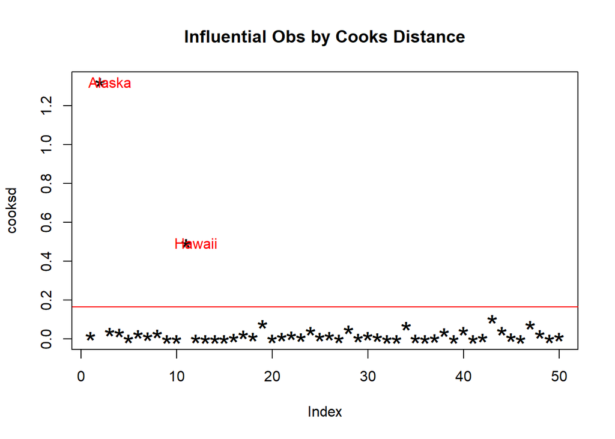

```r
plot(cooksd, pch="*", cex=2, main="Influential Obs by Cooks Distance")  # plot cook's distance
abline(h = 3*mean(cooksd, na.rm=T), col="red")  # add cutoff line
# add labels
text(x=1:length(cooksd)+1, y=cooksd, labels=ifelse(cooksd>3*mean(cooksd, na.rm=T),names(cooksd),""), col="red")
```

```r
# Observations
influential.obs <- names(cooksd)[(cooksd > 3*mean(cooksd, na.rm=T))]  # influential row names
influential.obs
```

```
## [1] "Alaska" "Hawaii"
```

```r
head(state77[influential.obs, ])  # influential observations (rows)
```

```
##        Population Income Illiteracy Life.Exp Murder HS.Grad Frost   Area
## Alaska        365   6315        1.5    69.31   11.3    66.7   152 566432
## Hawaii        868   4963        1.9    73.60    6.2    61.9     0   6425
```

Se detectan 2 observaciones con distancias Cook’s mayores que 3 veces la media: “**Alaska**” and “**Hawaii**”. Las variables Area y Frost en estas observaciones pueden estar influenciando. Estas observaciones no corresponden a datos aberrantes, por lo tanto se mantienen durante el análisis.

# Exercise 3: Analisis de la Variabilidad de las Variables (Removing Zero Covariates)

Se usa la función nearZeroVar() del paquete caret para buscar las variables que tengan “varianza casi cero”, aquellas que entre las dos categorías más numerosas tengan una relación de 90/10 y que tengan menos de 10 valores únicos. Dado que no hay ninguna con NZV=0, todas son utilizadas en el analisis.

```r
library(caret)
nzv = nearZeroVar(state77, freqCut = 90/10, uniqueCut = 10, saveMetrics = TRUE)
nzv
```

```
##            freqRatio percentUnique zeroVar   nzv
## Population         1           100   FALSE FALSE
## Income             1           100   FALSE FALSE
## Illiteracy         2            40   FALSE FALSE
## Life.Exp           1            94   FALSE FALSE
## Murder             1            88   FALSE FALSE
## HS.Grad            1            94   FALSE FALSE
## Frost              1            86   FALSE FALSE
## Area               1           100   FALSE FALSE
```

No hay variables para eliminar.

# Exercise 4: Correlation Matrix y Multicolinealidad

```r
tiff(file = "Matriz_de_Correlacion_State77.png", width=960, height=960, bg="white")
chart.Correlation(state77, histogram=TRUE, pch="*", method = c("spearman"))
dev.off()
```

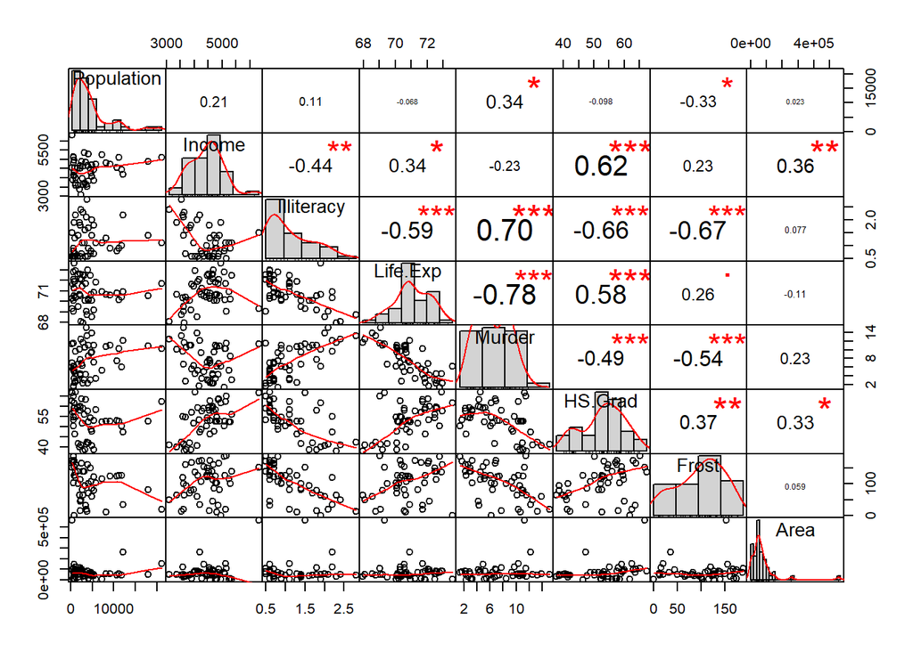

```r
chart.Correlation(state77, histogram=TRUE, pch="*", method = c("spearman"))
```

```r
# Multicolinealidad
vif(out.model)
```

```
## Population     Income Illiteracy     Murder    HS.Grad      Frost
##     1.4999     1.9927     4.4032     2.6165     3.1349     2.3582
##       Area
##     1.7898
```

Factor de Inflación de la Varianza (VIF):  
* VIF (Variance Inflation Factor) = 1: ausencia total de colinealidad.  
* 1 < VIF < 5: la regresión puede verse afectada por cierta colinealidad.  
* 5 < VIF < 10: causa de preocupación!

# Exercise 5: Model 1

```r
model1 <- lm(Life.Exp ~ ., data = state77)     # the '.' means 'all'
summary(model1)
```

```
##
## Call:
## lm(formula = Life.Exp ~ ., data = state77)
##
## Residuals:
##      Min       1Q   Median       3Q      Max
## -1.48895 -0.51232 -0.02747  0.57002  1.49447
##
## Coefficients:
##               Estimate Std. Error t value Pr(>|t|)
## (Intercept)  7.094e+01  1.748e+00  40.586  < 2e-16 ***
## Population   5.180e-05  2.919e-05   1.775   0.0832 .
## Income      -2.180e-05  2.444e-04  -0.089   0.9293
## Illiteracy   3.382e-02  3.663e-01   0.092   0.9269
## Murder      -3.011e-01  4.662e-02  -6.459 8.68e-08 ***
## HS.Grad      4.893e-02  2.332e-02   2.098   0.0420 *
## Frost       -5.735e-03  3.143e-03  -1.825   0.0752 .
## Area        -7.383e-08  1.668e-06  -0.044   0.9649
## ---
## Signif. codes:  0 '***' 0.001 '**' 0.01 '*' 0.05 '.' 0.1 ' ' 1
##
## Residual standard error: 0.7448 on 42 degrees of freedom
## Multiple R-squared:  0.7362, Adjusted R-squared:  0.6922
## F-statistic: 16.74 on 7 and 42 DF,  p-value: 2.534e-10
```

# Exercise 6: Model 2

```r
model2 <- update(model1, . ~ . -Income -Illiteracy -Area)
summary(model2)
```

```
##
## Call:
## lm(formula = Life.Exp ~ Population + Murder + HS.Grad + Frost,
##     data = state77)
##
## Residuals:
##      Min       1Q   Median       3Q      Max
## -1.47095 -0.53464 -0.03701  0.57621  1.50683
##
## Coefficients:
##               Estimate Std. Error t value Pr(>|t|)
## (Intercept)  7.103e+01  9.529e-01  74.542  < 2e-16 ***
## Population   5.014e-05  2.512e-05   1.996  0.05201 .
## Murder      -3.001e-01  3.661e-02  -8.199 1.77e-10 ***
## HS.Grad      4.658e-02  1.483e-02   3.142  0.00297 **
## Frost       -5.943e-03  2.421e-03  -2.455  0.01802 *
## ---
## Signif. codes:  0 '***' 0.001 '**' 0.01 '*' 0.05 '.' 0.1 ' ' 1
##
## Residual standard error: 0.7197 on 45 degrees of freedom
## Multiple R-squared:  0.736,  Adjusted R-squared:  0.7126
## F-statistic: 31.37 on 4 and 45 DF,  p-value: 1.696e-12
```

# Exercise 7: Model 3

```r
model3 <- lm(Life.Exp ~ HS.Grad + Murder, data = state77)
summary(model3)
```

```
##
## Call:
## lm(formula = Life.Exp ~ HS.Grad + Murder, data = state77)
##
## Residuals:
##      Min       1Q   Median       3Q      Max
## -1.66758 -0.41801  0.05602  0.55913  2.05625
##
## Coefficients:
##             Estimate Std. Error t value Pr(>|t|)
## (Intercept) 70.29708    1.01567  69.213  < 2e-16 ***
## HS.Grad      0.04389    0.01613   2.721  0.00909 **
## Murder      -0.23709    0.03529  -6.719 2.18e-08 ***
## ---
## Signif. codes:  0 '***' 0.001 '**' 0.01 '*' 0.05 '.' 0.1 ' ' 1
##
## Residual standard error: 0.7959 on 47 degrees of freedom
## Multiple R-squared:  0.6628, Adjusted R-squared:  0.6485
## F-statistic:  46.2 on 2 and 47 DF,  p-value: 8.016e-12
```

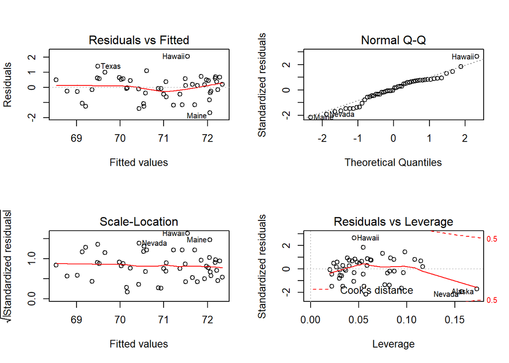

```r
par(mfrow=c(2,2))
plot(model3)
```

# Exercise 8: Model 4, 5, 6

```r
model4  <-  lm(Life.Exp ~ HS.Grad+Murder + HS.Grad:Murder, data = state77)
summary(model4)
```

```
##
## Call:
## lm(formula = Life.Exp ~ HS.Grad + Murder + HS.Grad:Murder, data = state77)
##
## Residuals:
##      Min       1Q   Median       3Q      Max
## -1.66077 -0.43846  0.06362  0.52665  1.99416
##
## Coefficients:
##                 Estimate Std. Error t value Pr(>|t|)
## (Intercept)    67.831203   2.530131  26.809   <2e-16 ***
## HS.Grad         0.089368   0.045684   1.956   0.0565 .
## Murder          0.023510   0.247487   0.095   0.9247
## HS.Grad:Murder -0.004959   0.004661  -1.064   0.2930
## ---
## Signif. codes:  0 '***' 0.001 '**' 0.01 '*' 0.05 '.' 0.1 ' ' 1
##
## Residual standard error: 0.7948 on 46 degrees of freedom
## Multiple R-squared:  0.6709, Adjusted R-squared:  0.6495
## F-statistic: 31.26 on 3 and 46 DF,  p-value: 3.592e-11
```

```r
model5  <-  lm(Life.Exp ~ HS.Grad*Murder, data = state77)
summary(model5)
```

```
##
## Call:
## lm(formula = Life.Exp ~ HS.Grad * Murder, data = state77)
##
## Residuals:
##      Min       1Q   Median       3Q      Max
## -1.66077 -0.43846  0.06362  0.52665  1.99416
##
## Coefficients:
##                 Estimate Std. Error t value Pr(>|t|)
## (Intercept)    67.831203   2.530131  26.809   <2e-16 ***
## HS.Grad         0.089368   0.045684   1.956   0.0565 .
## Murder          0.023510   0.247487   0.095   0.9247
## HS.Grad:Murder -0.004959   0.004661  -1.064   0.2930
## ---
## Signif. codes:  0 '***' 0.001 '**' 0.01 '*' 0.05 '.' 0.1 ' ' 1
##
## Residual standard error: 0.7948 on 46 degrees of freedom
## Multiple R-squared:  0.6709, Adjusted R-squared:  0.6495
## F-statistic: 31.26 on 3 and 46 DF,  p-value: 3.592e-11
```

```r
model6  <-  lm(Life.Exp ~ (HS.Grad+Murder)^2, data = state77)
summary(model6)
```

```
##
## Call:
## lm(formula = Life.Exp ~ (HS.Grad + Murder)^2, data = state77)
##
## Residuals:
##      Min       1Q   Median       3Q      Max
## -1.66077 -0.43846  0.06362  0.52665  1.99416
##
## Coefficients:
##                 Estimate Std. Error t value Pr(>|t|)
## (Intercept)    67.831203   2.530131  26.809   <2e-16 ***
## HS.Grad         0.089368   0.045684   1.956   0.0565 .
## Murder          0.023510   0.247487   0.095   0.9247
## HS.Grad:Murder -0.004959   0.004661  -1.064   0.2930
## ---
## Signif. codes:  0 '***' 0.001 '**' 0.01 '*' 0.05 '.' 0.1 ' ' 1
##
## Residual standard error: 0.7948 on 46 degrees of freedom
## Multiple R-squared:  0.6709, Adjusted R-squared:  0.6495
## F-statistic: 31.26 on 3 and 46 DF,  p-value: 3.592e-11
```

# Exercise 9: Confidence Intervals

```r
confint(model3, level=0.95)
```

```
##                   2.5 %      97.5 %
## (Intercept) 68.25382379 72.34034424
## HS.Grad      0.01144419  0.07633041
## Murder      -0.30807483 -0.16610536
```

# Exercise 10: Predict

```r
predict(model3, data.frame(HS.Grad=55, Murder=8))
```

```
##        1
## 70.81416
```

# Exercise 11: Predict (Confidence)

Los intervalos pueden incluir la incertidumbre sobre los coeficientes estimados (**confidence**), la varianza (“noise”) en las observaciones, o ambos (**predicción**). Por lo tanto, un intervalo de predicción siempre es más amplio que un intervalo de confianza. Una es la predicción de una observación futura, y la otra es una predicción de la respuesta media.

```r
predict(model3, data.frame(HS.Grad=55, Murder=8), interval = "confidence", level=0.95)
```

```
##        fit      lwr      upr
## 1 70.81416 70.56997 71.05836
```

# Exercise 12: Predict (Prediction)

Los intervalos pueden incluir la incertidumbre sobre los coeficientes estimados (**confidence**), la varianza (“noise”) en las observaciones, o ambos (**predicción**). Por lo tanto, un intervalo de predicción siempre es más amplio que un intervalo de confianza. Una es la predicción de una observación futura, y la otra es una predicción de la respuesta media.

```r
predict(model3, data.frame(HS.Grad=55, Murder=8), interval = "prediction", level=0.95)
```

```
##        fit      lwr      upr
## 1 70.81416 69.19456 72.43377
```

# Exercise 13: Plot

```r
plotdat <- expand.grid(HS.Grad = seq(34, 70, by=2), Murder = seq(1, 16, by=1))
plotdat$pred1 <- predict(model3, newdata = plotdat)

with(state77, plot3d(HS.Grad, Murder, Life.Exp, col="blue", size=1, type="s"))
with(plotdat, surface3d(unique(HS.Grad), unique(Murder), pred1, alpha=0.5, front="line", back="line"))

rglwidget(height = 1000, width = 1000)
```

[interactive chart not shown]

# Exercise 14: Stepwise

```r
reducedModel <- step(model1, direction = "both") # Stepwise method, doble o mixto
```

```
## Start:  AIC=-22.18
## Life.Exp ~ Population + Income + Illiteracy + Murder + HS.Grad +
##     Frost + Area
##
##              Df Sum of Sq    RSS     AIC
## - Area        1    0.0011 23.298 -24.182
## - Income      1    0.0044 23.302 -24.175
## - Illiteracy  1    0.0047 23.302 -24.174
## <none>                    23.297 -22.185
## - Population  1    1.7472 25.044 -20.569
## - Frost       1    1.8466 25.144 -20.371
## - HS.Grad     1    2.4413 25.738 -19.202
## - Murder      1   23.1411 46.438  10.305
##
## Step:  AIC=-24.18
## Life.Exp ~ Population + Income + Illiteracy + Murder + HS.Grad +
##     Frost
##
##              Df Sum of Sq    RSS     AIC
## - Illiteracy  1    0.0038 23.302 -26.174
## - Income      1    0.0059 23.304 -26.170
## <none>                    23.298 -24.182
## - Population  1    1.7599 25.058 -22.541
## + Area        1    0.0011 23.297 -22.185
## - Frost       1    2.0488 25.347 -21.968
## - HS.Grad     1    2.9804 26.279 -20.163
## - Murder      1   26.2721 49.570  11.569
##
## Step:  AIC=-26.17
## Life.Exp ~ Population + Income + Murder + HS.Grad + Frost
##
##              Df Sum of Sq    RSS     AIC
## - Income      1     0.006 23.308 -28.161
## <none>                    23.302 -26.174
## - Population  1     1.887 25.189 -24.280
## + Illiteracy  1     0.004 23.298 -24.182
## + Area        1     0.000 23.302 -24.174
## - Frost       1     3.037 26.339 -22.048
## - HS.Grad     1     3.495 26.797 -21.187
## - Murder      1    34.739 58.041  17.456
##
## Step:  AIC=-28.16
## Life.Exp ~ Population + Murder + HS.Grad + Frost
##
##              Df Sum of Sq    RSS     AIC
## <none>                    23.308 -28.161
## + Income      1     0.006 23.302 -26.174
## + Illiteracy  1     0.004 23.304 -26.170
## + Area        1     0.001 23.307 -26.163
## - Population  1     2.064 25.372 -25.920
## - Frost       1     3.122 26.430 -23.877
## - HS.Grad     1     5.112 28.420 -20.246
## - Murder      1    34.816 58.124  15.528
```

```r
summary(reducedModel)
```

```
##
## Call:
## lm(formula = Life.Exp ~ Population + Murder + HS.Grad + Frost,
##     data = state77)
##
## Residuals:
##      Min       1Q   Median       3Q      Max
## -1.47095 -0.53464 -0.03701  0.57621  1.50683
##
## Coefficients:
##               Estimate Std. Error t value Pr(>|t|)
## (Intercept)  7.103e+01  9.529e-01  74.542  < 2e-16 ***
## Population   5.014e-05  2.512e-05   1.996  0.05201 .
## Murder      -3.001e-01  3.661e-02  -8.199 1.77e-10 ***
## HS.Grad      4.658e-02  1.483e-02   3.142  0.00297 **
## Frost       -5.943e-03  2.421e-03  -2.455  0.01802 *
## ---
## Signif. codes:  0 '***' 0.001 '**' 0.01 '*' 0.05 '.' 0.1 ' ' 1
##
## Residual standard error: 0.7197 on 45 degrees of freedom
## Multiple R-squared:  0.736,  Adjusted R-squared:  0.7126
## F-statistic: 31.37 on 4 and 45 DF,  p-value: 1.696e-12
```

# Exercise 15: k-fold Cross Validation

Nota: dado que el set datos contiene pocas observaciones no se recomienda partirlo en train y test set. Se sugiere utilizar la metodologia K-fold Cross Validation.

Por tanto, es importante probar rigurosamente el rendimiento del modelo tanto como sea posible. Una forma es asegurarse de que la ecuación del modelo que se propone tiene funcione bien, cuando se ‘construye’ en un subconjunto diferente de datos de entrenamiento y se predice con los datos restantes.

Para hacer esto vamos a dividir los datos de entrada en ‘k’ porciones de muestras aleatorias mutuamente excluyentes. Manteniendo cada porción como datos de prueba, construimos el modelo final sugerido sobre los datos restantes (parte k-1) y calculamos el error cuadrático medio de las predicciones (MSE). Esto se hace para cada una de las porciones de muestra aleatoria ‘k’. Luego, finalmente, se calcula el promedio de estos errores cuadráticos medios (para las porciones ‘k’), y su equivalente RMSE (Root Mean Square Error or Deviation).

Al hacer esto, debemos verificar dos cosas:

=> Si la precisión de predicción del modelo no varía demasiado para una muestra en particular, y  
=> Si las líneas de mejor ajuste no varían demasiado con respecto a la pendiente y el nivel.

```r
library(DAAG)
# Performs the CV
cvResults <- suppressWarnings(CVlm(data=na.omit(state77),
                                   form.lm=Life.Exp ~ Population + Murder + HS.Grad + Frost,
                                   m=3,
                                   dots=FALSE,
                                   seed=29,
                                   legend.pos="topleft",
                                   printit=FALSE,
                                   main="k- Fold Cross Validation"))
```

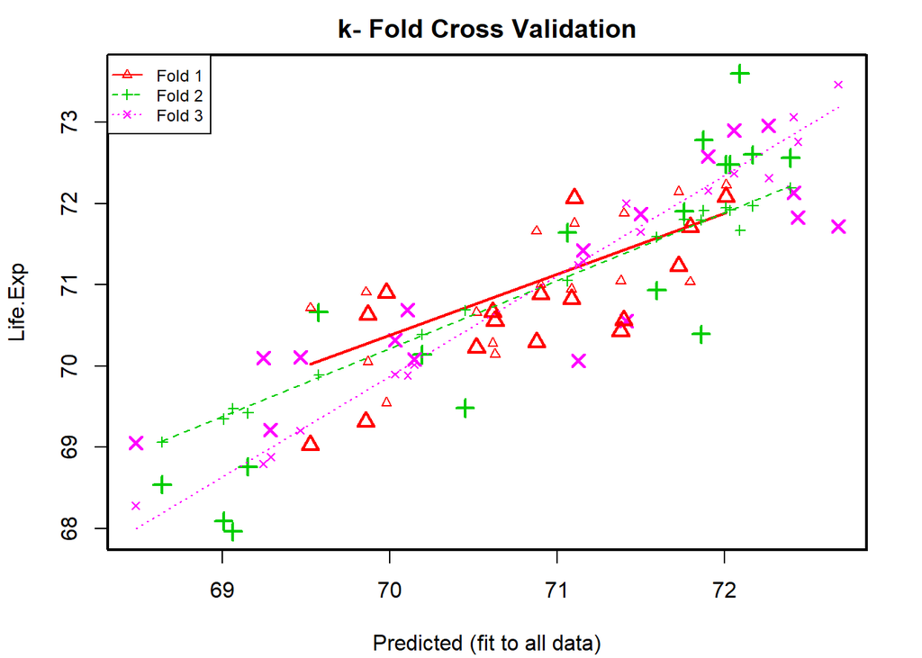

```r
sqrt(attr(cvResults, 'ms')) # Root Mean Squared Error - RMSE (Error rate)
```

```
## [1] 0.9144629
```

```r
cvResults
```

[output not shown]

[output cut: 47 more lines]

```
## Oklahoma        68782  71.15860 71.29414
## Oregon          96184  72.41445 73.06096
## Pennsylvania    44966  71.38046 71.04628
## Rhode Island     1049  71.76007 71.79856
## South Carolina  30225  69.06109 69.47381
## South Dakota    75955  72.01161 72.22944
## Tennessee       41328  69.46583 69.20349
## Texas          262134  69.97886 69.54314
## Utah            82096  72.05753 72.36719
## Vermont          9267  71.06135 71.04834
## Virginia        39780  70.14691 70.01284
## Washington      66570  72.68272 73.46339
## West Virginia   24070  70.44983 70.68404
## Wisconsin       54464  72.00996 71.94582
## Wyoming         97203  70.87679 71.65646
```

Los resultados de la validacion cruzada utilizando 3 porciones de muestras mutuamente excluyentes, revelan que, el modelo propuesto presenta una baja desviacion o dispersion de los datos en la prediccion, con un RMSE de 0.9 años; que es bastante bueno.